# Course Project Part 2

Brian Ritz

Saturday, February 21, 2015

```r
Part2.Data<-read.csv(file="../input/MScA_LinearNonLinear_CourseProject_Part2.csv")
Part2.Data<-as.data.frame(cbind(Part2.Data,Part2.Data[,2]/60))
colnames(Part2.Data)<-c("Times","Counts","Temperatures","Intensities")
head(Part2.Data)
```

```
##   Times Counts Temperatures Intensities
## 1    30      7     91.59307  0.11666667
## 2    90     10     97.30860  0.16666667
## 3   150      7     95.98865  0.11666667
## 4   210      4    100.38440  0.06666667
## 5   270      1     99.98330  0.01666667
## 6   330      6    102.54126  0.10000000
```

Visualize the data

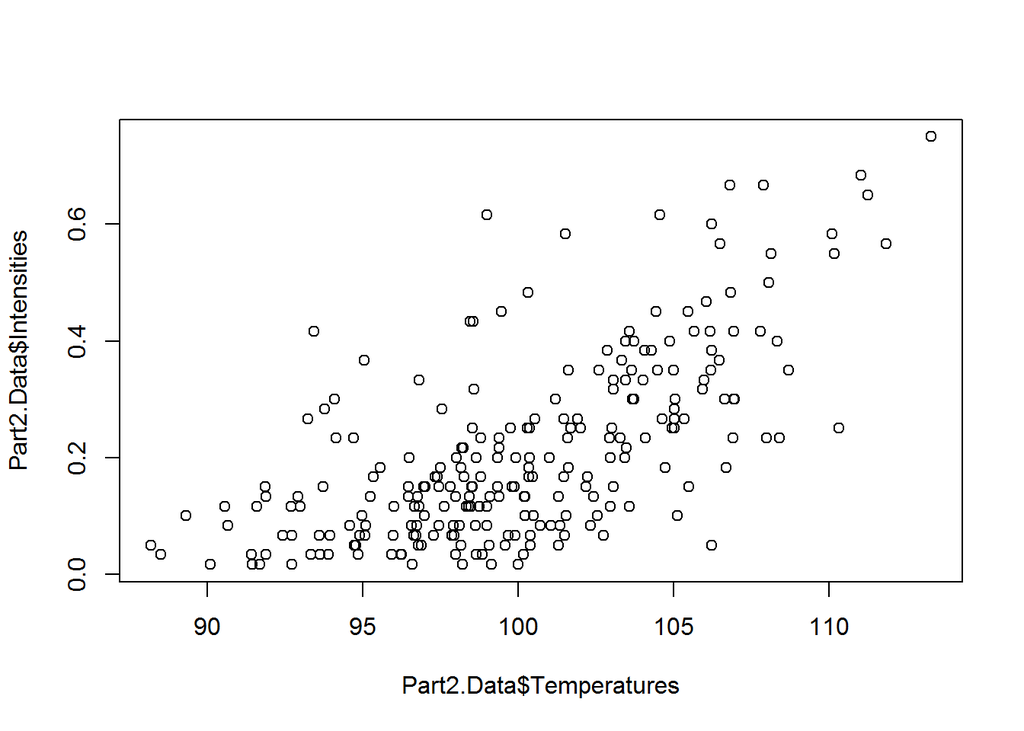

```r
plot(Part2.Data$Temperatures,Part2.Data$Intensities)
```

**Interpret the plot. What type od relationship you observe?** I observe a comonotonic relationship – as temperatures increase, so does the temperature. However, the relationship does not look linear. It appears that the slope increases as the temperature rises.

Empirical copula should be normalized– divide all by n, so all numbersare between 0 and 1.

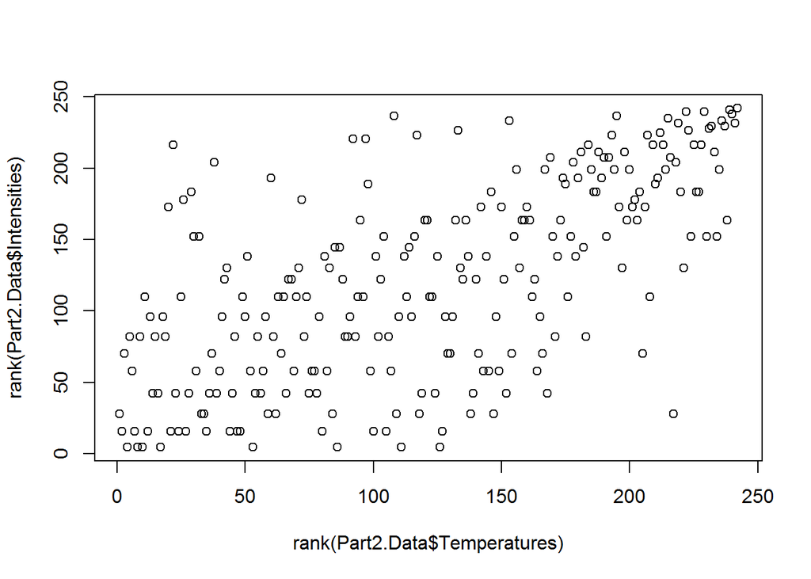

```r
plot(rank(Part2.Data$Temperatures),rank(Part2.Data$Intensities))
```

We see comonotonic behavior, and tail dependence – pinched corners. We should investigate this. We are seeing Gumbel’s copula (there is upper tail dependence).

What is the distribution of temperatures?

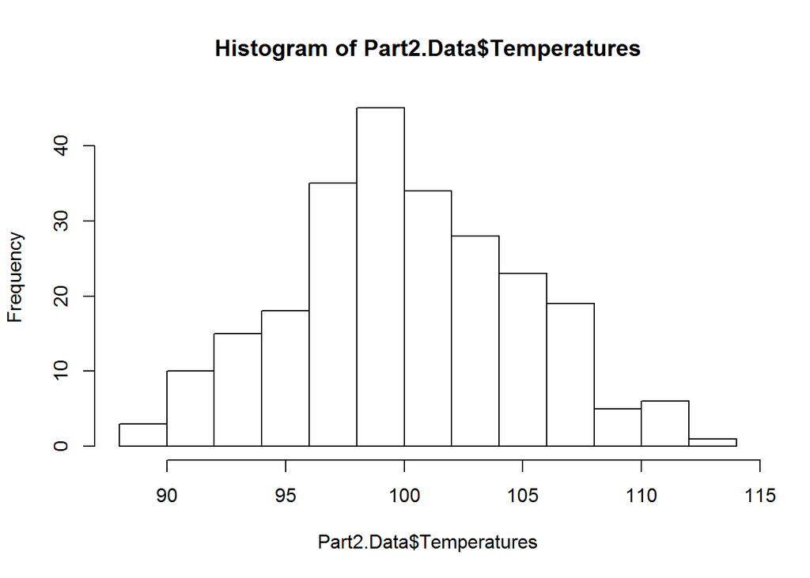

```r
hist(Part2.Data$Temperatures)
```

The distribution looks fairly normal, however there aren’t as many high temperatures as expected.

We test if it is normal.

```r
library(MASS)
ks.test(Part2.Data$Temperatures, "pnorm", mean=mean(Part2.Data$Temperatures), sd=sd(Part2.Data$Temperatures))
```

```
##
##  One-sample Kolmogorov-Smirnov test
##
## data:  Part2.Data$Temperatures
## D = 0.049, p-value = 0.6071
## alternative hypothesis: two-sided
```

```r
library(copula)
Copula.Object<-gumbelCopula(param=5,dim=2)
Copula.Fit<-fitCopula(Copula.Object,
                       pobs(Part2.Data[c("Temperatures", "Intensities")],ties.method = "average"),
                      method="ml",
                      optim.method="BFGS",
                      optim.control = list(maxit=1000))
Copula.Fit
```

```
## fitCopula() estimation based on 'maximum likelihood'
## and a sample of size 242.
##       Estimate Std. Error z value Pr(>|z|)
## param  1.87746    0.09899   18.97   <2e-16 ***
## ---
## Signif. codes:  0 '***' 0.001 '**' 0.01 '*' 0.05 '.' 0.1 ' ' 1
## The maximized loglikelihood is  74.18
## Optimization converged
## Number of loglikelihood evaluations:
## function gradient
##       11        4
```

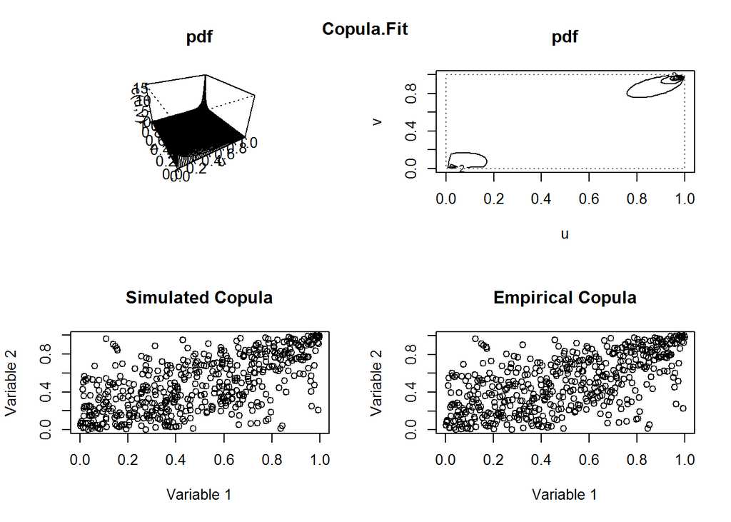

```r
par(mfrow=c(2,2))
set.seed(8301735)
Defined.copula<-gumbelCopula(param=summary(Copula.Fit)$coefficients[1,1],dim=2)
persp(Defined.copula, dCopula, main="pdf",xlab="u", ylab="v", zlab="c(u,v)")
contour(Defined.copula,dCopula, main="pdf",xlab="u", ylab="v")
Simulated.Gumbel.Copula<-rCopula(500,Defined.copula)
plot(Simulated.Gumbel.Copula,main="Simulated Copula",xlab="Variable 1",ylab="Variable 2")
plot(apply(Simulated.Gumbel.Copula,2,rank)/length(Simulated.Gumbel.Copula[,1]),main="Empirical Copula",xlab="Variable 1",ylab="Variable 2")
title("Copula.Fit",outer=TRUE,line=-2)
```

```r
Gamma.Rate<- 8.132
Gamma.Shape<-1.656
Fit.Normal<- c(mean(Part2.Data$Temperatures),sd(Part2.Data$Temperatures))
```

WE now how two distributions – one is gamma, one is normal … fit copula and simulate now.

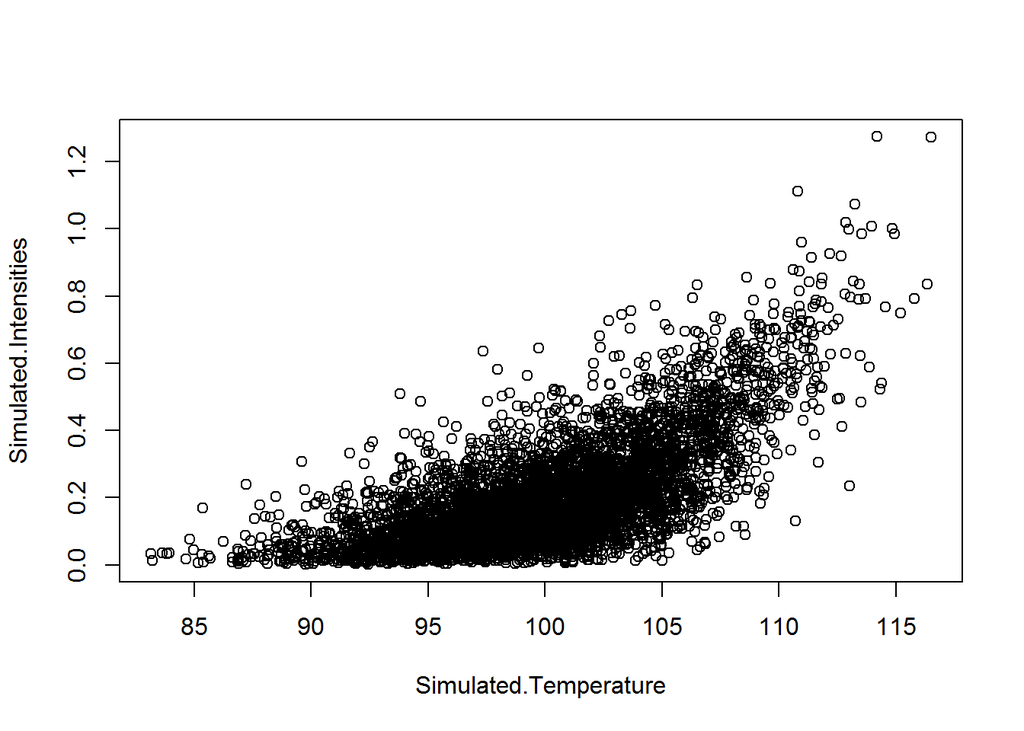

```r
par(mfrow=c(1,1))
Simulated.Copula <- rCopula(5000, Defined.copula)
Simulated.Intensities<-qgamma(Simulated.Copula[,1], shape=Gamma.Shape, scale=1/Gamma.Rate)
Simulated.Temperature<-qnorm(Simulated.Copula[,2],Fit.Normal[1],Fit.Normal[2])
plot(Simulated.Temperature,Simulated.Intensities)
```